## Simulated Percentage of Interhouse Swipes Compared to Actual Percentage of Interhouse Swipes

### Model Explanation

Each distribution in the below plot represents the hypothetical distributions of interhouse swipes if each house had an equal chance of observing any percentage of interhouse swipes from the data. In other words, I randomly assigned houses to the observed percentages of interhouse swipes and then plotted the resulting distributions. These distributions represent what the interhouse swipe percentages would look like if each house had an equal probability of observing the different percentages of interhouse swipes from our data. The vertical lines for each plot represent the true percentage of interhouse swipes for each house over the two academic years. The distance from the vertical line and the distribution illustrates how far each house’s percentage of interhouse swipes lies from average.

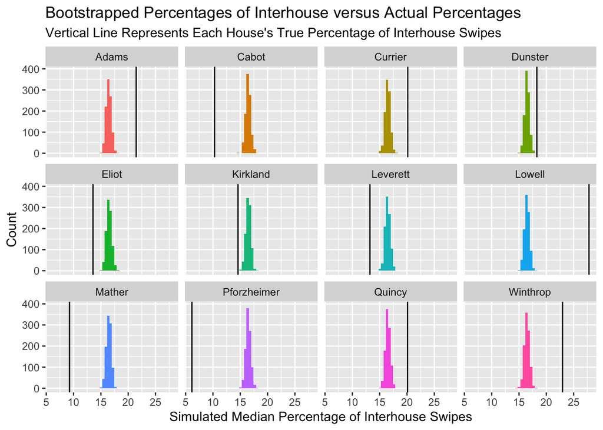

## Discussion

### River Central

River Central is the only neighborhood where all of its houses have a greater percentage of interhouse swipes than average. This relative anomaly makes sense because of the neighborhood’s relative proximity to the center of campus. For the 2017-2018 and 2018-2019 academic years, Lowell dining took place in the “Lowtel” swing housing facility just outside the gates of Tercentenary Theater. This location, as well as Adams and Quincy only require a few minutes of walking for those coming from class in the Yard or Tercentenary Theater. I hypothesize that the majority of interhouse swipes at these three locations came from students living in other housing neighborhoods. Students in these houses might as well walk to their own house, but the relative proximity of River Central houses makes any of them extra alluring to students from other neighborhoods

### The Quad

Not surprisingly, Cabot and Pforzheimer have a significantly smaller percentage of interhouse swipes than if these percentages were randomly assigned. Somewhat surprisingly, however, Currier has a greater than average percentage of interhouse swipes. I hypothesize that Currier interhouse swipes largely come from other Quad residents. Students living in the Quad have already made the hike home to their own house. However, they may have a preference for Currier’s allegedly “superior” dining facility and food quality since it definitely is not a convenient location. Students living in Currier often do boast that their dining hall reigns supreme to all others, and this data point seems to confirm that Currier’s dining is more desirable than the other Quad houses.

### River East

Winthrop appears to be students’ top choice when they are dining in River East. While Kirkland has the closes location to the Yard, students may opt for Winthrop because the new renovations add a sense of novelty to the experience.

### River West

Following the theme seen in River East, Dunster has the greatest percentage of interhouse swipes out of the three River West Houses and it is the only with a percentage that is either at or above average for interhouse swipes. Potentially the newly renovated houses do indeed attract more interhouse diners. The trend seems to hold true for Winthrop and Dunster, so this is something to keep an eye on in future years for Lowell and Adams following the conclusion of renovations.